# Results (PhD Chapter 3)

This series of files compile all analyses done during Chapter 3.

All analyses have been done with R 4.0.1.

> Click on the table of contents in the left margin to assess a specific analysis.  
> Click on a figure to zoom it

**This page is under construction, updates will arrive soon!**

# 1. Rank-Frequency diagrams

These diagrams have been created for each campaign and their respective condition/region, to compare their communities.

##### 2014

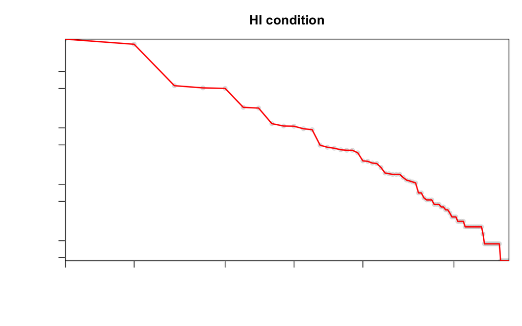

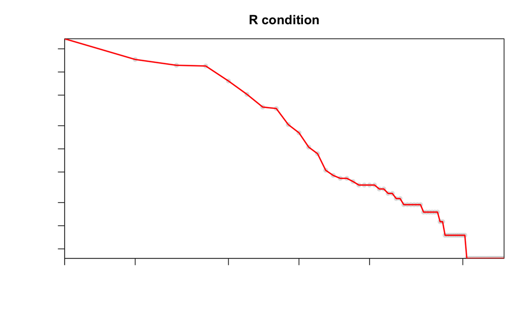

##### 2016

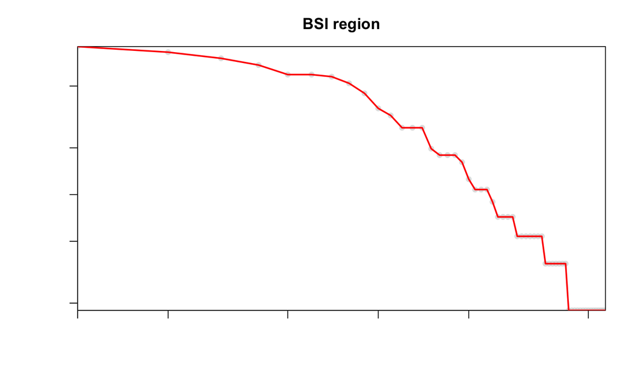

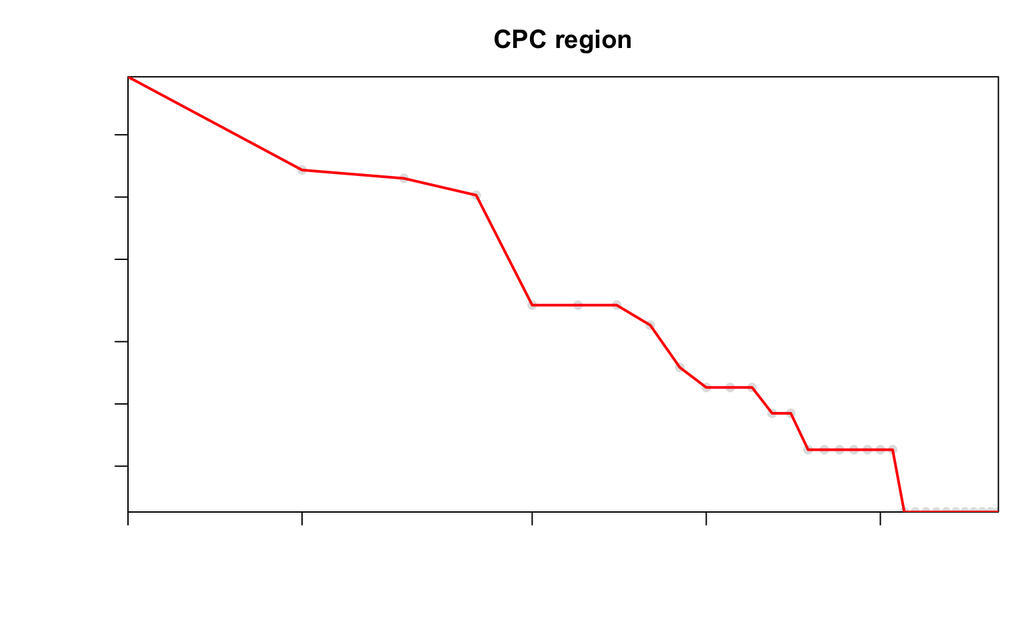

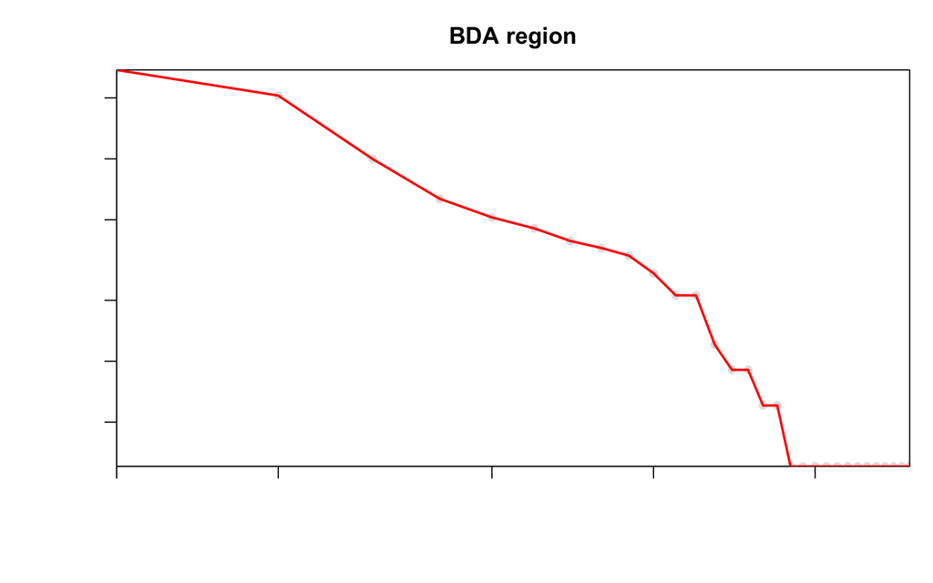

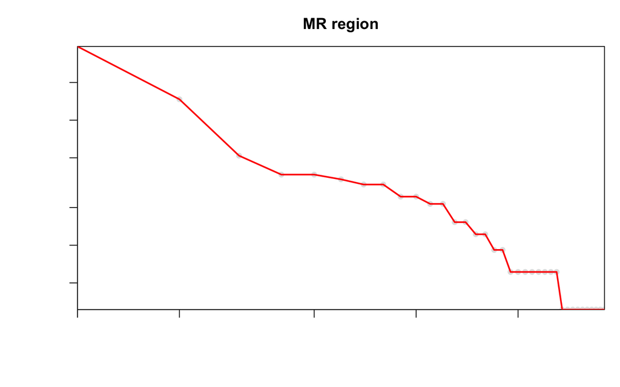

##### 2017

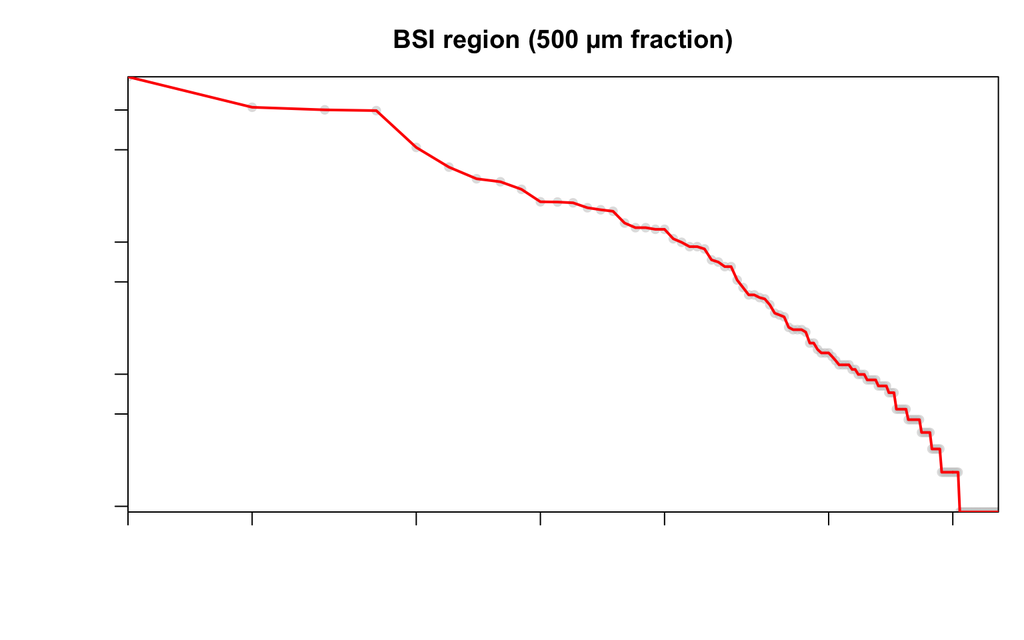

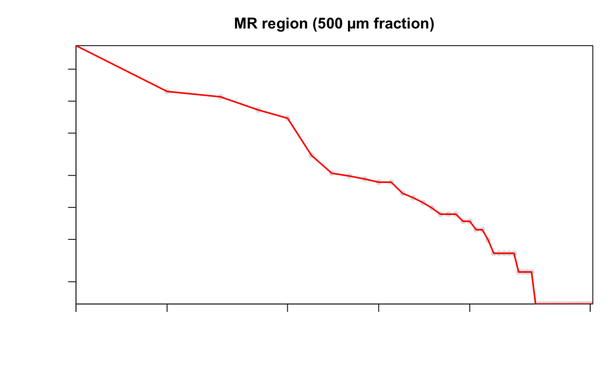

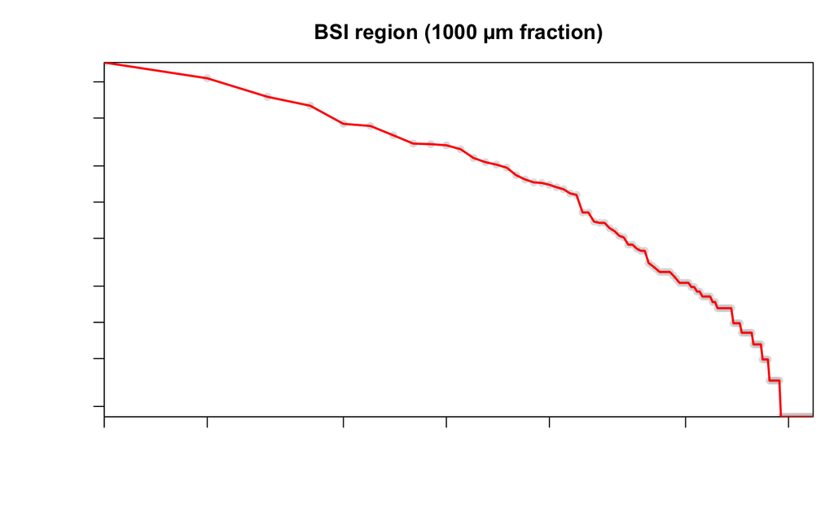

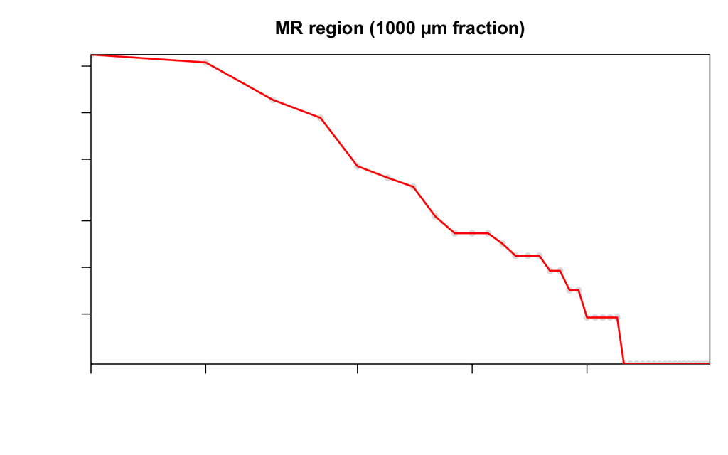

# 2. AMBI and M-AMBI indices

## 2.1. Calculations of reference values

These values are needed for the M-AMBI index to copute ecological quality ratios (EQR). We will analyse only **BSI stations**, with a seperation between fractions 500 µm and 1000 µm.

**Values below will be called “reference” based on the assumption that the higher the species richness/shannon index is, the better the ecological quality is. But this vision is limited and can have limitations, so it must be further discussed.**

The reference value for species richness/shannon index is not set as the maximum of the distribution, but at the **95th percentile**. This recommendation is by Nicolas Desroy, so that we do not have an increase of EQR when there is a small perturbation (see work by Pearson & Rosenberg and the Intermediate Disturbance Hypothesis).

Through this calculation process, we obtain these values:

| Fraction | 500 µm (shallow) | 500 µm (deep) | 1000 µm (shallow) | 1000 µm (deep) |
| --- | --- | --- | --- | --- |
| S | 26 | 22 | 12 | 16 |
| H | 2.15 | 2.54 | 1.84 | 2.38 |

## 2.2. Maps

The following maps represent AMBI values and M-AMBI status for each station at BSI. A discrimination has been done between the 500 and 1000 µm fractions, and for shallow (< 15 m) and deep stations (> 15 m) according to salinity-temperature plots.

The colour code has been uniformed with the European EQR classification, from “High” ecological status in blue to “Bad” in red.

No clear tendancy can be discovered here, apart from the fact that the overall status seems to be “High” in the BSI. Several hypothesises can explain this result:

- the M-AMBI index describes reality well, so that overall perturbation from organic matter is low
- there is a bias in the index due to the species classification in groups, originally suited for European ecosystems
- the assumption that the higher species richness and Shannon diversity are, the higher the ecological status of an ecosystem is, is not correct
- the configuration of the BSI makes the perturbation small relative to the water volume and bathymetric condition

More work is needed to determine the individual responses of somes species, along with the use of different methods to understand other perturbations and cumulatic impacts.

##### 500 µm (shallow)

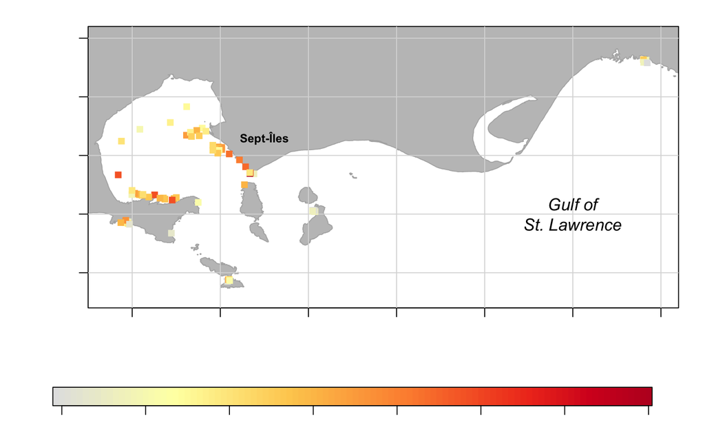

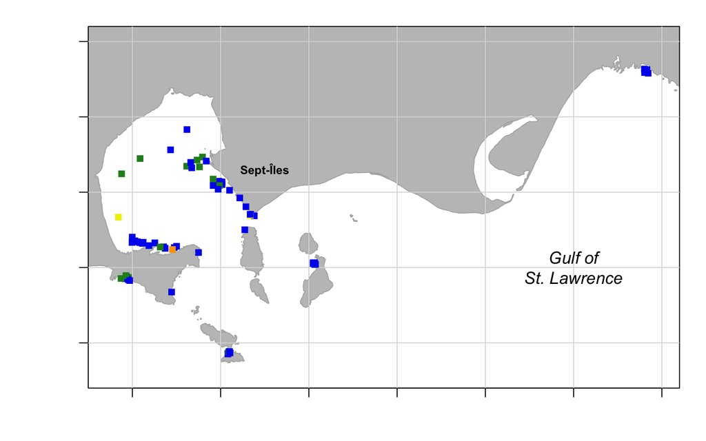

##### 500 µm (deep)

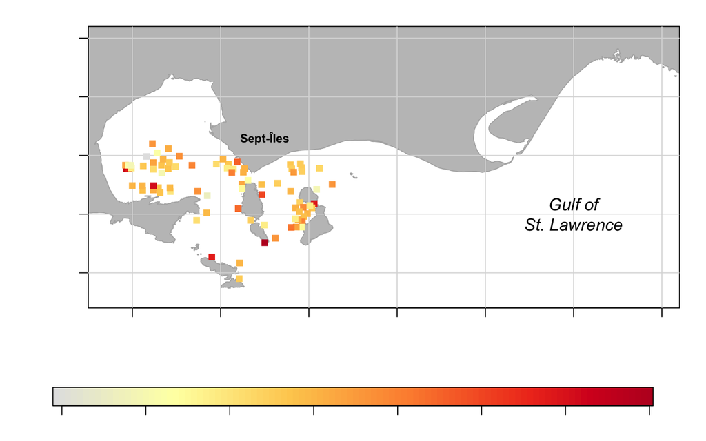

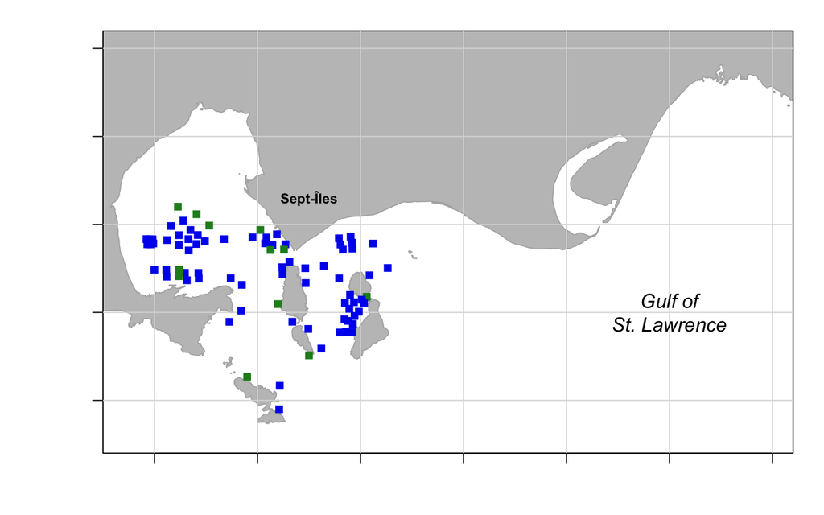

##### 1000 µm (shallow)

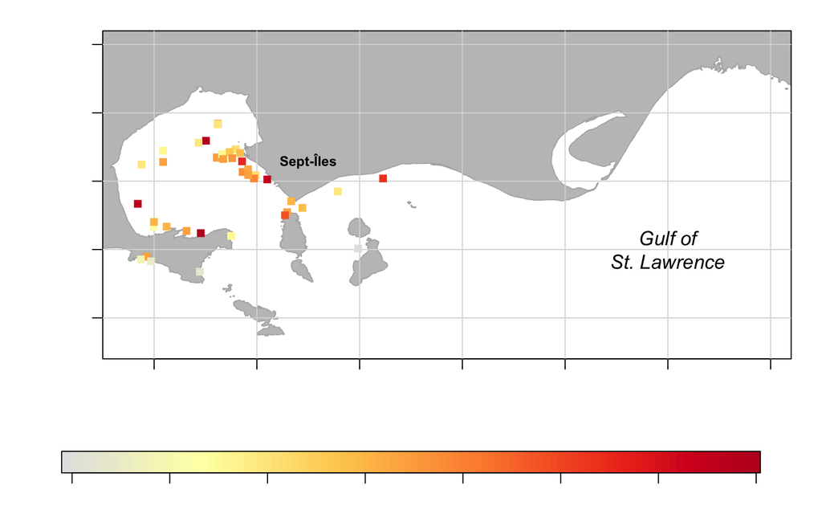

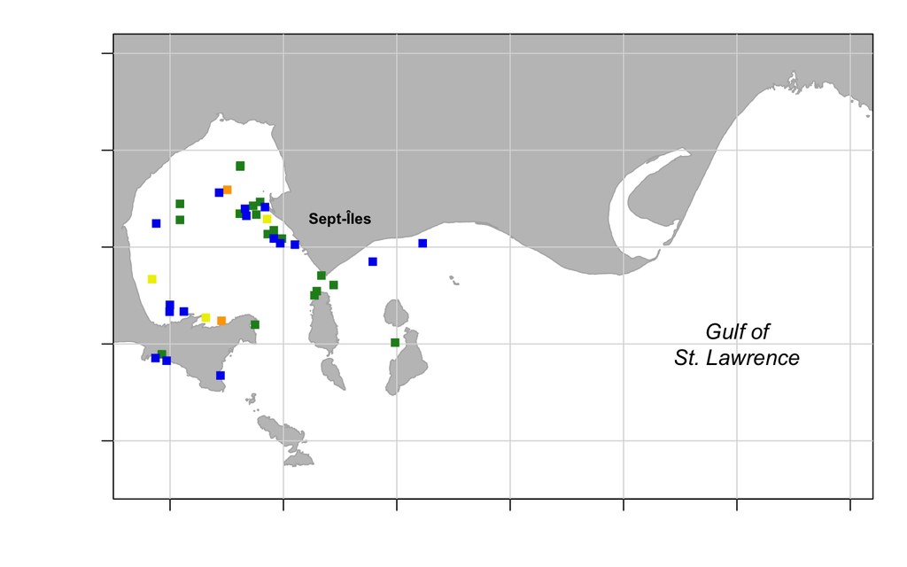

##### 1000 µm (deep)

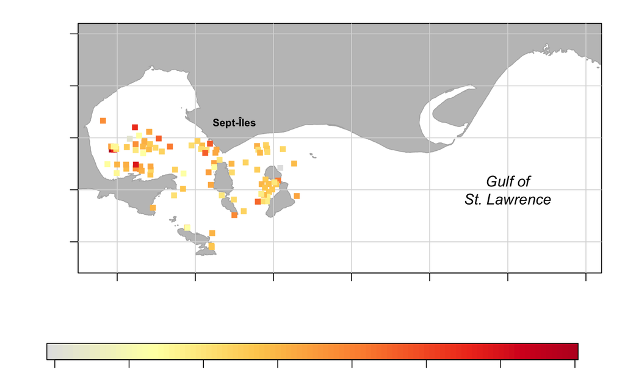

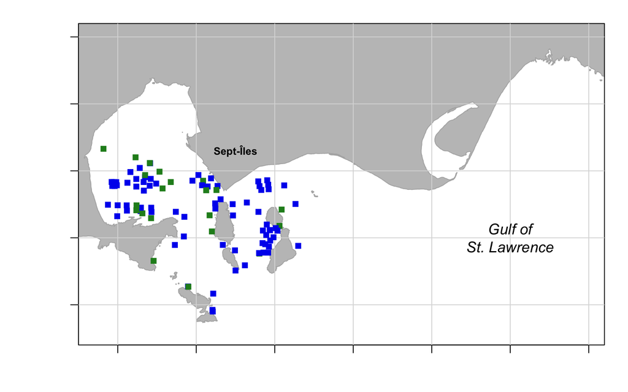

# 3. BenthoVal index

This index is a work-in-progress by the team of Céline Labrune and Olivier Gauthier at IFREMER. This pressure score still **needs to be enhanced** so that more human activities are included and the score is better defined.

[🏠](https://eldre.github.io/eldre-phd/)